# Behavioral Cloning

### Project 3 of Udacity's Self-Driving Car Engineer Nanodegree program

This is the third project of the nanodegree in which you have to train a self-driving car to adapt to a human's driving style using a convolutional neural network which has to predict the steering angle using prerecorded training data of a human driver.

[figure not shown]

```python
from IPython.display import YouTubeVideo
YouTubeVideo('Dx1JrIlXiDM')
```

[video not shown]

### Library import

```python
import csv
import cv2
import numpy as np
import matplotlib.pyplot as plt
import pandas as pd
%matplotlib inline

import tensorflow as tf
from keras.models import Sequential
from keras.layers import Flatten, Dense, Lambda, Cropping2D, Dropout
from keras.layers.convolutional import Conv2D
from keras.layers.pooling import MaxPooling2D
from keras.optimizers import Adam
```

## Training data configuration

```python
# learning_sets = ["Session_4_Track_1_Insane"]
#learning_sets = ["Session_4_Track_1_Insane", "Session_1_Track_1", "Session_2_Track_1_Reverse", "Session_6_Bridge",
#                 "Session_7_Bridge", "Session_8_Bridge", "Session_9_Track_1_Curves"]
# Works, but curvey:
# learning_sets = ["Session_4_Track_1_Insane", "Session_6_Bridge", "Session_7_Bridge", "Session_8_Bridge", "Session_9_Track_1_Curves"]
# Works not, too perfect driving style:
# learning_sets = ["Session_4_Track_1_Insane", "Session_6_Bridge", "Session_7_Bridge", "Session_8_Bridge"]
# Works not, too perfect driving style:
# learning_sets = ["Session_4_Track_1_Insane", "Session_1_Track_1", "Session_2_Track_1_Reverse", "Session_6_Bridge", "Session_7_Bridge", "Session_8_Bridge"]
# Works not, too insensitive:
# learning_sets = ["Session_1_Track_1", "Session_2_Track_1_Reverse", "Session_6_Bridge", "Session_7_Bridge", "Session_8_Bridge"]
# Track 1 final - Perfect mix of driving styles:
# learning_sets = ["Session_1_Track_1", "Session_2_Track_1_Reverse", "Session_6_Bridge", "Session_7_Bridge", "Session_8_Bridge", "Session_9_Track_1_Curves"]
# Track 2:
learning_sets = ["Session_5_Track_2_Great", "Session_3_Track_2", "Session_10_Track_2_Perfect"]
#learning_sets = ["Session_1_Track_1", "Session_2_Track_1_Reverse", "Session_6_Bridge", "Session_7_Bridge", "Session_8_Bridge"]
base_data_path = "training_data/"
```

## Splitting the CSV data into file names and measurements

Here we first of all read the CSV and prepare the relative paths to all images of all training sessions.

```python
image_filenames = [] # array of tuple of images for center/left/right
measurements = [] # array of measurements

for learning_set_path in learning_sets:

    print("Loading {}...".format(learning_set_path))

    pdcsv = pd.read_csv(base_data_path+learning_set_path+"/driving_log.csv")

    print(pdcsv.shape)

    for index, line in pdcsv.iterrows():
        source_path = line[0]
        filename_0 = source_path.split('/')[-1]
        source_path = line[1]
        filename_1 = source_path.split('/')[-1]
        source_path = line[2]
        filename_2 = source_path.split('/')[-1]
        base_path = base_data_path+learning_set_path+"/IMG/"
        image_filenames.append((base_path+filename_0, base_path+filename_1, base_path+filename_2))
        measurement = float(line[3])
        measurements.append(measurement)

print("{} images and {} measurements prepared".format(len(image_filenames), len(measurements)))

center_example = len(image_filenames)//2
```

```
Loading Session_5_Track_2_Great...
(6201, 7)
Loading Session_3_Track_2...
(4433, 7)
Loading Session_10_Track_2_Perfect...
(5499, 7)
16133 images and 16133 measurements prepared
```

```python
def get_full_training_image_path(index, direction):
    """Returns the full path to an image at given index and using a specific direction

    index: The image index
    direction: The camera index. 0 = straight view camera, 1 = left side, 2 = right side
    """
    return image_filenames[index][direction]
```

```python
print(get_full_training_image_path(center_example,0))
```

```
training_data/Session_3_Track_2/IMG/center_2018_04_29_13_33_51_664.jpg
```

## Presenting example images

Below you can see an image of all 3 cameras, the straight camera, the left camera and the right camera.

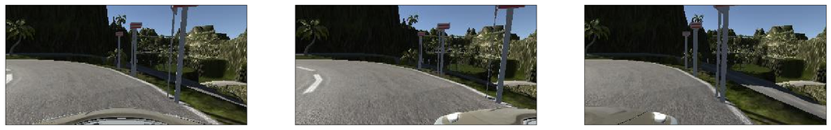

```python
columns = 3
rows = 1
total_samples = columns*rows

fig = plt.figure(figsize=(columns*10,rows*10))

for i in range(total_samples):
    ax = fig.add_subplot(rows, columns, i + 1, xticks=[], yticks=[])
    filename = get_full_training_image_path(center_example,i)
    cur_org = cv2.imread(filename)
    b,g,r = cv2.split(cur_org)       # get b,g,r
    cur_org = cv2.merge([r,g,b])     # switch it to rgb

    ax.imshow(cur_org)
```

## Image loading and augmentation

```python
augmented_images = []
augmented_measurements = []

for index, ifn in enumerate(image_filenames):
    for side in range(1):
        image = cv2.imread(get_full_training_image_path(index,side))
        b,g,r = cv2.split(image)       # get b,g,r
        image = cv2.merge([r,g,b])     # switch it to rgb
        measurement = measurements[index]
        if side==1:
            measurement += 0.1
        if side==2:
            measurement -= 0.1

        augmented_images.append(image)
        augmented_measurements.append(measurement)
        augmented_images.append(cv2.flip(image,1))
        augmented_measurements.append(-measurement)

print(len(augmented_images))
print(augmented_images[0].shape)
```

```
32266
(160, 320, 3)
```

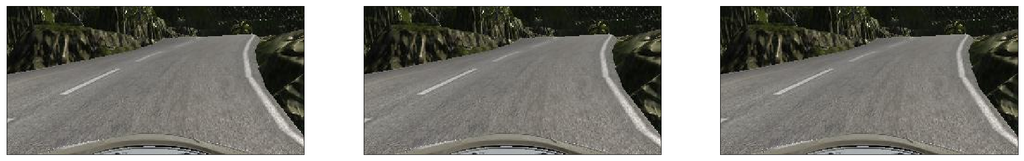

```python
columns = 3
rows = 1
total_samples = columns*rows

fig = plt.figure(figsize=(columns*10,rows*10))

for i in range(total_samples):
    ax = fig.add_subplot(rows, columns, i + 1, xticks=[], yticks=[])
    filename = get_full_training_image_path(center_example,i)
    cur_org = augmented_images[100]

    ax.imshow(cur_org)
```

## Image cropping test

To let the network focus on the really important parts of the image we crop away the upper and lower part of the image as the clouds likely won't help us to better predict the perfect steering angle.

```
(160, 320, 3)
```

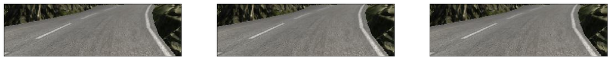

```python
columns = 3
rows = 1
total_samples = columns*rows

crop_percent_top = 0.2
crop_percent_bottom = 0.2

fig = plt.figure(figsize=(columns*10,rows*10))

for i in range(total_samples):
    ax = fig.add_subplot(rows, columns, i + 1, xticks=[], yticks=[])
    filename = get_full_training_image_path(center_example,i)
    cur_org = augmented_images[100]

    width = cur_org.shape[1]
    height = cur_org.shape[0]
    top_off = int(crop_percent_top*height)
    rem_height = int(height-(crop_percent_bottom+crop_percent_top)*height)
    cur_org = cur_org[top_off:top_off+rem_height, :, :]

    ax.imshow(cur_org)

print(augmented_images[0].shape)
```

## Training and exporting the model

When everything is prepared we feed all of this data into a convolutional neural network with 5 convolutional and 4 fully connected layers.

Instead of using the neural network to try to categorize and image or detect something within it we use it to predict the steering angle. So for example if it detects lane lines pretty close the the left side of the vehicle it shall steer to the right and if it detects ones close to the right side it shall steer to the left. If it's perfectly in the center of the road it shall not steer at all.

```python
# Convert the training data to numpy tensors

X_train = np.array(augmented_images)
y_train = np.array(augmented_measurements)


# Setup a sequential, convolutional network which predicts the optimum steering angle in different situations
model = Sequential()
# The original input image is cropped and normalized. Storing this in the model makes it possible to automatically
# crop the image from the simulator as well
model.add(Lambda(lambda x: x/127.5 - 1.0, input_shape=(160, 320, 3)))
model.add(Cropping2D(cropping=((60,12),(0,0))))
# 5 convolutional layers, nVidia style, first three layers use a 5x5, the other two ones a 3x3 kernel
model.add(Conv2D(24,(5,5),strides=(2,2),activation="relu"))
model.add(Conv2D(36,(5,5),strides=(2,2),activation="relu"))
model.add(Conv2D(48,(5,5),strides=(2,2),activation="relu"))
model.add(Conv2D(64,(3,3),activation="relu"))
model.add(Conv2D(64,(3,3),activation="relu"))
# Flatten the data and add another 3 fully connected layers
model.add(Flatten())
# To prevent overfitting enable dropout of 25%
model.add(Dropout(0.25))
model.add(Dense(100))
# To prevent overfitting enable dropout of 25%
model.add(Dropout(0.25))
model.add(Dense(50))
model.add(Dense(10))
model.add(Dense(1))

model.compile(loss='mse', optimizer=Adam())

model.fit(X_train, y_train, validation_split=0.2, shuffle=True, epochs=8)

model.save('model.h5')
```

```
Train on 25812 samples, validate on 6454 samples
```

```python
from IPython.display import SVG
from keras.utils.vis_utils import model_to_dot

def plot_keras_model(model, show_shapes=True, show_layer_names=True):
    return SVG(model_to_dot(model, show_shapes=show_shapes, show_layer_names=show_layer_names).create(prog='dot',format='svg'))


file = open('model.svg', 'w')
file.write(svg_data.data)
file.close()

svg_data = plot_keras_model(model, show_shapes=True, show_layer_names=False)
plot_keras_model(model, show_shapes=True, show_layer_names=False)
```

[figure not shown]